# PART 1

# Q1. Please refer the table below to answer below questions:

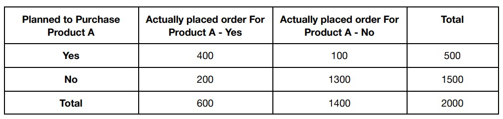

# Q1.A Refer above table and find the joint probability of the people who planned to purchase and actually placed an order

Answer: Joint probability of the people who planned to purchase and actually placed an order = 400/2000 = 0.2

# Q1.B Refer to the above table and find the joint probability of the people who planned to purchase and actually placed an order, given that people planned to purchase.

Answer: Joint probability of the people who planned to purchase and actually placed an order, given that people planned to purchase = 400/500 = 0.8

Q2. An electrical manufacturing company conducts quality checks at specified periods on the products it manufactures. Historically, the failure rate for the manufactured item is 5%. Suppose a random sample of 10 manufactured items is selected. Answer the following questions. A. Probability that none of the items are defective? [1 Mark] B. Probability that exactly one of the items is defective? [1 Mark] C. Probability that two or fewer of the items are defective? [1 Mark] D. Probability that three or more of the items are defective ? [1 Mark]

A. Probability that none of the items are defective? n=10; p=0.05; q=0.95; Binomial Distribution P(X=0)

```python
import scipy.stats as stats
from scipy.stats import binom
import matplotlib.pyplot as plt
n, p = 10, 0.05
mean, var, skew, kurt = binom.stats(n, p, moments='mvsk')
prob = binom.pmf(0, 10, 0.05)
```

```python
print('P(X=0)=', prob)
```

```
P(X=0)= 0.5987369392383787
```

B. Probability that exactly one of the items is defective?

```python
prob1 = binom.pmf(1, 10, 0.05)
print('P(X=1)=', prob1)
```

```
P(X=1)= 0.3151247048623047
```

C. Probability that two or fewer of the items are defective? i.e P(X<=2)=P(0)+P(1)+P(2)

```python
prob2 = binom.pmf(2, 10, 0.05)
print('P(X=2)=', prob2)
```

```
P(X=2)= 0.07463479852001963
```

```python
print('P(X<=2)=P(0)+P(1)+P(2)=', prob+prob1+prob2)
```

```
P(X<=2)=P(0)+P(1)+P(2)= 0.988496442620703
```

```python
prob3 = binom.pmf(3, 10, 0.05)
print('P(X=3)=', prob3)
```

```
P(X=3)= 0.010475059441406236
```

```python
print('P(X>=3)=1-(P(0)+P(1)+P(2)+P(3))=',(1-(prob+prob1+prob2+prob3)))
```

```
P(X>=3)=1-(P(0)+P(1)+P(2)+P(3))= 0.0010284979378907266
```

Q3. A car salesman sells on an average 3 cars per week. A. What is Probability that in a given week he will sell some cars. [1 Mark] B. What is Probability that in a given week he will sell 2 or more but less than 5 cars. [1 Mark] C. Plot the poisson distribution function for cumulative probability of cars sold per-week vs number of cars sold per week. [1 Mark]

A. What is Probability that in a given week he will sell some cars. Poisson Dsitribution P(X>0)=1-P(X=0)

```python
from scipy.stats import poisson
prob = poisson.pmf(0, 3)
print('Probability that in a given week he will sell some cars:',prob)
```

[output not shown]

B. What is Probability that in a given week he will sell 2 or more but less than 5 cars. P(X=2,3,4)

```python
from scipy.stats import poisson
prob1=poisson.pmf(1, 3)
prob2=poisson.pmf(2, 3)
prob3 = poisson.pmf(3, 3)
prob4=poisson.pmf(4, 3)
print('Probability that in a given week he will sell 2 or more but less than 5 cars:',prob2+prob3+prob4)
```

```
Probability that in a given week he will sell 2 or more but less than 5 cars: 0.6161149710523164
```

C. Plot the poisson distribution function for cumulative probability of cars sold per-week vs number of cars sold per week.

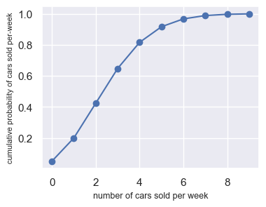

```python
f = plt.figure()
f.set_figwidth(4)
f.set_figheight(3)
k = np.arange(0, 10)
cdf = poisson.cdf(k, mu=3)
plt.plot(k,cdf,marker='o')
plt.xlabel('number of cars sold per week',fontsize=9)
plt.ylabel('cumulative probability of cars sold per-week',fontsize=8)
```

Q4. Accuracy in understanding orders for a speech based bot at a restaurant is important for the Company X which has designed, marketed and launched the product for a contactless delivery due to the COVID-19 pandemic. Recognition accuracy that measures the percentage of orders that are taken correctly is 86.8%. Suppose that you place an order with the bot and two friends of yours independently place orders with the same bot. Answer the following questions. A. What is the probability that all three orders will be recognised correctly? [1 Mark] B. What is the probability that none of the three orders will be recognised correctly? [1 Mark] C. What is the probability that at least two of the three orders will be recognised correctly? [1 Mark]

A. What is the probability that all three orders will be recognised correctly?

```python
prb0 = binom.pmf(0, 3, 0.868)
print('probability that all three orders will be recognised correctly:', (1-prb0))
```

[output not shown]

B. What is the probability that none of the three orders will be recognised correctly?

```python
prb0 = binom.pmf(0, 3, 0.868)
prb1=binom.pmf(1, 3, 0.868)
print(' probability that none of the three orders will be recognised correctly:',prb0)
```

```
 probability that none of the three orders will be recognised correctly: 0.0022999680000000003
```

C. What is the probability that at least two of the three orders will be recognised correctly?

```python
prb2 = binom.pmf(2, 3, 0.868)
prb3 = binom.pmf(3, 3, 0.868)
print('probability that at least two of the three orders will be recognised correctly:',(prb2+prb3))
#print('probability that at least two of the three orders will be recognised correctly:',1-(prb0+prb1))
```

```
probability that at least two of the three orders will be recognised correctly: 0.952327936
```

Q5. Explain 1 real life industry scenario (other than the ones mentioned above) where you can use the concepts learnt in this module of Applied statistics to get a data driven business solution.

Spotify, on-demand music-providing platform, collects data from all its users around the globe, applies statistical concepts and uses the analyzed data to give informed music recommendations and suggestions to every individual user.The few of the data collected consists of fields like year of music,language,type of music,name of singers,name of music director,period of music etc.

# PART 2 Domain:Sports

```python
#1. Read the data set, clean the data and prepare final dataset to be used for analysis
```

```python
import numpy as np
import pandas as pd
import matplotlib.pyplot as plt
import seaborn as sns
bball = pd.read_csv('D:\\Great Learning\\Applied Statistics\\Project\\Basketball.csv')
```

```python
bball.head()
```

|  | Team | Tournament | Score | PlayedGames | WonGames | DrawnGames | LostGames | BasketScored | BasketGiven | TournamentChampion | Runner-up | TeamLaunch | HighestPositionHeld |
| --- | --- | --- | --- | --- | --- | --- | --- | --- | --- | --- | --- | --- | --- |
| 0 | Team 1 | 86 | 4385 | 2762 | 1647 | 552 | 563 | 5947 | 3140 | 33 | 23 | 1929 | 1 |
| 1 | Team 2 | 86 | 4262 | 2762 | 1581 | 573 | 608 | 5900 | 3114 | 25 | 25 | 1929 | 1 |
| 2 | Team 3 | 80 | 3442 | 2614 | 1241 | 598 | 775 | 4534 | 3309 | 10 | 8 | 1929 | 1 |
| 3 | Team 4 | 82 | 3386 | 2664 | 1187 | 616 | 861 | 4398 | 3469 | 6 | 6 | 1931to32 | 1 |
| 4 | Team 5 | 86 | 3368 | 2762 | 1209 | 633 | 920 | 4631 | 3700 | 8 | 7 | 1929 | 1 |

```python
#1. clean the data and prepare final dataset to be used for analysis
```

```python
# Replace all '-' with 0
bball.replace(to_replace='-', value=0, inplace=True)
#bball['TeamLaunch'] = bball['TeamLaunch'].str[:4]

# Correction for TeamLaunch column
bball['TeamLaunch'] = bball['TeamLaunch'].apply(lambda year: str(year)[:4])
```

```python
bball
```

|  | Team | Tournament | Score | PlayedGames | WonGames | DrawnGames | LostGames | BasketScored | BasketGiven | TournamentChampion | Runner-up | TeamLaunch | HighestPositionHeld |
| --- | --- | --- | --- | --- | --- | --- | --- | --- | --- | --- | --- | --- | --- |
| 0 | Team 1 | 86 | 4385 | 2762 | 1647 | 552 | 563 | 5947 | 3140 | 33 | 23 | 1929 | 1 |
| 1 | Team 2 | 86 | 4262 | 2762 | 1581 | 573 | 608 | 5900 | 3114 | 25 | 25 | 1929 | 1 |
| 2 | Team 3 | 80 | 3442 | 2614 | 1241 | 598 | 775 | 4534 | 3309 | 10 | 8 | 1929 | 1 |
| 3 | Team 4 | 82 | 3386 | 2664 | 1187 | 616 | 861 | 4398 | 3469 | 6 | 6 | 1931 | 1 |
| 4 | Team 5 | 86 | 3368 | 2762 | 1209 | 633 | 920 | 4631 | 3700 | 8 | 7 | 1929 | 1 |
| ... | ... | ... | ... | ... | ... | ... | ... | ... | ... | ... | ... | ... | ... |
| 56 | Team 57 | 1 | 34 | 38 | 8 | 10 | 20 | 38 | 66 | 0 | 0 | 2009 | 20 |
| 57 | Team 58 | 1 | 22 | 30 | 7 | 8 | 15 | 37 | 57 | 0 | 0 | 1956 | 16 |
| 58 | Team 59 | 1 | 19 | 30 | 7 | 5 | 18 | 51 | 85 | 0 | 0 | 1951 | 16 |
| 59 | Team 60 | 1 | 14 | 30 | 5 | 4 | 21 | 34 | 65 | 0 | 0 | 1955 | 15 |
| 60 | Team 61 | 1 | 0 | 0 | 0 | 0 | 0 | 0 | 0 | 0 | 0 | 2017 | 9 |

61 rows × 13 columns

```python
bball.info()
```

```
<class 'pandas.core.frame.DataFrame'>
RangeIndex: 61 entries, 0 to 60
Data columns (total 13 columns):
 #   Column               Non-Null Count  Dtype
---  ------               --------------  -----
 0   Team                 61 non-null     object
 1   Tournament           61 non-null     int64
 2   Score                61 non-null     object
 3   PlayedGames          61 non-null     object
 4   WonGames             61 non-null     object
 5   DrawnGames           61 non-null     object
 6   LostGames            61 non-null     object
 7   BasketScored         61 non-null     object
 8   BasketGiven          61 non-null     object
 9   TournamentChampion   61 non-null     object
 10  Runner-up            61 non-null     object
 11  TeamLaunch           61 non-null     object
 12  HighestPositionHeld  61 non-null     int64
dtypes: int64(2), object(11)
memory usage: 6.3+ KB
```

```python
#Only tournament coloumn and HighestPositionHeld coloumn are of int64 type. All other coloumn values are string type.
#So except coloumn 0 all other coloumns have to be converted to int64 type for further calculations
cols = bball.columns
bball[cols[1:]] = bball[cols[1:]].astype('int64')
bball.info()
```

```
<class 'pandas.core.frame.DataFrame'>
RangeIndex: 61 entries, 0 to 60
Data columns (total 13 columns):
 #   Column               Non-Null Count  Dtype
---  ------               --------------  -----
 0   Team                 61 non-null     object
 1   Tournament           61 non-null     int64
 2   Score                61 non-null     int64
 3   PlayedGames          61 non-null     int64
 4   WonGames             61 non-null     int64
 5   DrawnGames           61 non-null     int64
 6   LostGames            61 non-null     int64
 7   BasketScored         61 non-null     int64
 8   BasketGiven          61 non-null     int64
 9   TournamentChampion   61 non-null     int64
 10  Runner-up            61 non-null     int64
 11  TeamLaunch           61 non-null     int64
 12  HighestPositionHeld  61 non-null     int64
dtypes: int64(12), object(1)
memory usage: 6.3+ KB
```

```python
# Describe the dataset with various summary and statistics
#Using describe() function find the
bball.describe()
```

|  | Tournament | Score | PlayedGames | WonGames | DrawnGames | LostGames | BasketScored | BasketGiven | TournamentChampion | Runner-up | TeamLaunch | HighestPositionHeld |
| --- | --- | --- | --- | --- | --- | --- | --- | --- | --- | --- | --- | --- |
| count | 61.000000 | 61.000000 | 61.000000 | 61.000000 | 61.000000 | 61.000000 | 61.000000 | 61.000000 | 61.000000 | 61.000000 | 61.000000 | 61.000000 |
| mean | 24.000000 | 901.426230 | 796.819672 | 303.967213 | 188.934426 | 303.754098 | 1140.344262 | 1140.229508 | 1.426230 | 1.409836 | 1958.918033 | 7.081967 |
| std | 26.827225 | 1134.899121 | 876.282765 | 406.991030 | 201.799477 | 294.708594 | 1506.740211 | 1163.710766 | 5.472535 | 4.540107 | 27.484114 | 5.276663 |
| min | 1.000000 | 0.000000 | 0.000000 | 0.000000 | 0.000000 | 0.000000 | 0.000000 | 0.000000 | 0.000000 | 0.000000 | 1929.000000 | 1.000000 |
| 25% | 4.000000 | 96.000000 | 114.000000 | 34.000000 | 24.000000 | 62.000000 | 153.000000 | 221.000000 | 0.000000 | 0.000000 | 1935.000000 | 3.000000 |
| 50% | 12.000000 | 375.000000 | 423.000000 | 123.000000 | 95.000000 | 197.000000 | 430.000000 | 632.000000 | 0.000000 | 0.000000 | 1951.000000 | 6.000000 |
| 75% | 38.000000 | 1351.000000 | 1318.000000 | 426.000000 | 330.000000 | 563.000000 | 1642.000000 | 1951.000000 | 0.000000 | 0.000000 | 1978.000000 | 10.000000 |
| max | 86.000000 | 4385.000000 | 2762.000000 | 1647.000000 | 633.000000 | 1070.000000 | 5947.000000 | 3889.000000 | 33.000000 | 25.000000 | 2017.000000 | 20.000000 |

```python
won_pct = bball['WonGames'] / bball['PlayedGames']
bball.insert(loc=5, column='WinningPercentage', value=won_pct)
los_pct = bball['LostGames'] / bball['PlayedGames']
bball.insert(loc=8, column='LoosingPercentage', value=los_pct)
win_ratio = bball['WonGames'] / bball['LostGames']
bball.insert(loc=9, column='WinningRatio', value=win_ratio)
bball.head()
```

|  | Team | Tournament | Score | PlayedGames | WonGames | WinningPercentage | DrawnGames | LostGames | LoosingPercentage | WinningRatio | BasketScored | BasketGiven | TournamentChampion | Runner-up | TeamLaunch | HighestPositionHeld |
| --- | --- | --- | --- | --- | --- | --- | --- | --- | --- | --- | --- | --- | --- | --- | --- | --- |
| 0 | Team 1 | 86 | 4385 | 2762 | 1647 | 0.596307 | 552 | 563 | 0.203838 | 2.925400 | 5947 | 3140 | 33 | 23 | 1929 | 1 |
| 1 | Team 2 | 86 | 4262 | 2762 | 1581 | 0.572411 | 573 | 608 | 0.220130 | 2.600329 | 5900 | 3114 | 25 | 25 | 1929 | 1 |
| 2 | Team 3 | 80 | 3442 | 2614 | 1241 | 0.474751 | 598 | 775 | 0.296480 | 1.601290 | 4534 | 3309 | 10 | 8 | 1929 | 1 |
| 3 | Team 4 | 82 | 3386 | 2664 | 1187 | 0.445571 | 616 | 861 | 0.323198 | 1.378630 | 4398 | 3469 | 6 | 6 | 1931 | 1 |
| 4 | Team 5 | 86 | 3368 | 2762 | 1209 | 0.437726 | 633 | 920 | 0.333092 | 1.314130 | 4631 | 3700 | 8 | 7 | 1929 | 1 |

# Univariate Analysis - To check individual distribution- Skewness

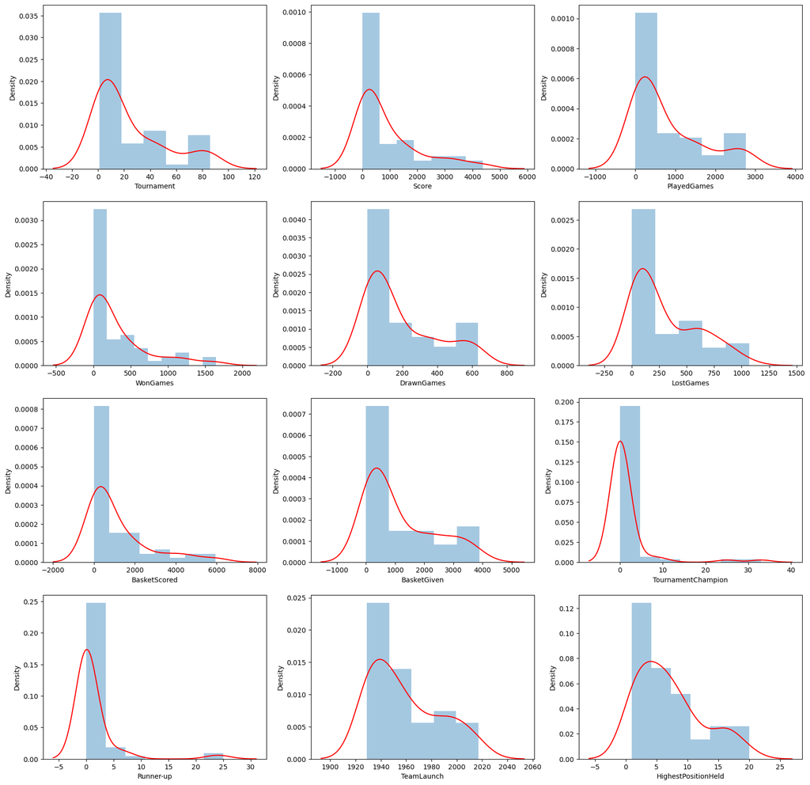

```python
attrs = ['Tournament','Score','PlayedGames','WonGames','DrawnGames','LostGames','BasketScored','BasketGiven','TournamentChampion','Runner-up','TeamLaunch','HighestPositionHeld']
plt.figure(figsize=(20,20))
index = 1
for col in bball[attrs]:
    plt.subplot(4,3,index)
    sns.distplot(bball[col],kde=True,kde_kws={"color": "r"})
    index += 1
```

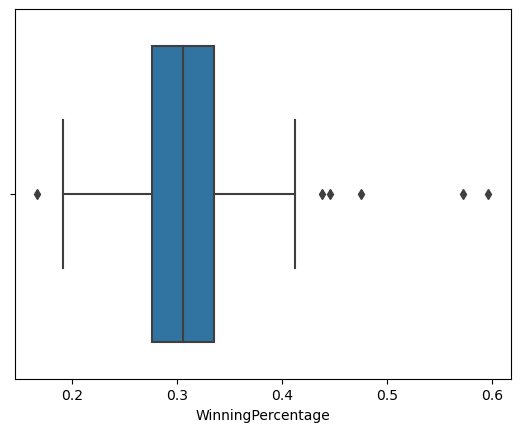

```python
sns.boxplot(x='WinningPercentage',data=bball)
```

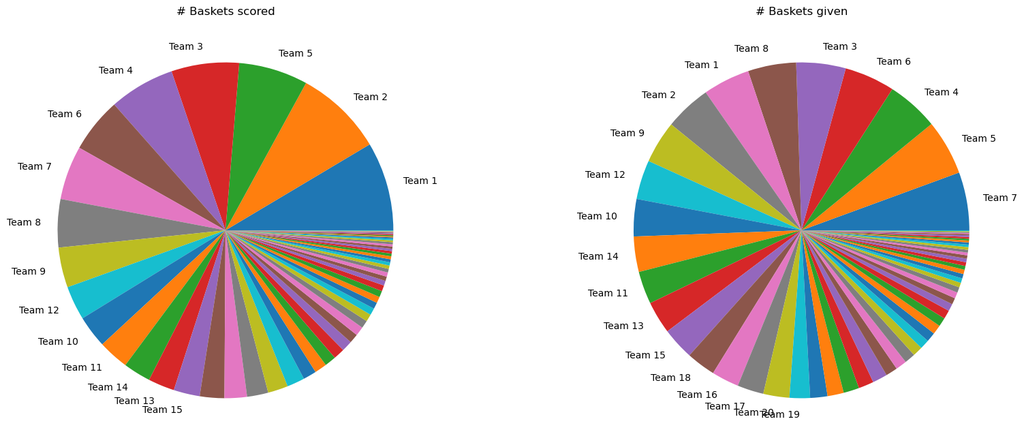

```python
# No of baskets scored/given by teams
plt.figure(figsize=(20,8))
plt.subplot(1,2,1)
bb = bball[['Team','BasketScored']].sort_values(by="BasketScored", ascending=False)
plot = plt.pie(bb['BasketScored'], labels=list(bb['Team'][:15]) + [str()] * (len(bb)-15))
plt.title('# Baskets scored')
plt.subplot(1,2,2)
bb = bball[['Team','BasketGiven']].sort_values(by="BasketGiven", ascending=False)
plot = plt.pie(bb['BasketGiven'], labels=list(bb['Team'][:20]) + [str()] * (len(bb)-20))
plt.title('# Baskets given')
```

# Bivariate Analysis

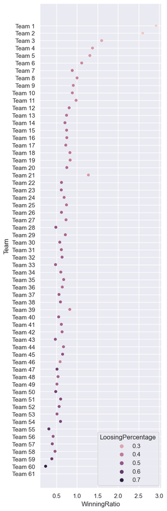

```python
ax=sns.scatterplot(data=bball, x="WinningRatio", y="Team",hue='LoosingPercentage')
sns.set(rc={"figure.figsize":(16, 16)})

plt.show()
```

# Multivariate Analysis

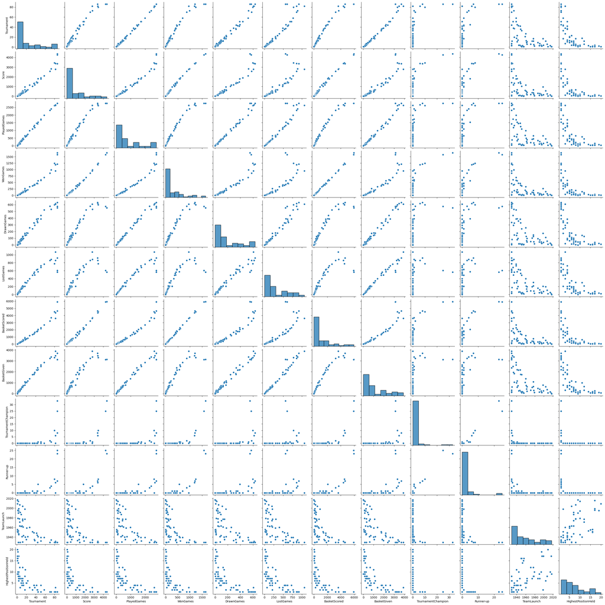

```python
sns.pairplot(bball[attrs])
```

1. Perform detailed statistical analysis and EDA using univariate, bi-variate and multivariate EDA techniques to get data driven insights on recommending which teams they can approach which will be a deal win for them. Also as a data and statistics expert you have to develop a detailed performance report using this data.

```
1)Team 1, Team 2 and Team 5 played the most tournament matches but Team 1 and Team 2 happens to be the highest average scorrer.
2)Team 1 seems to be a team with matured experience and game.
3)Team 2 also exhibit fine and profound game skills as they are the one appearing the most in the leaderboard as runner-up
```

```
Quality of data: Null values can be avoided
Quantity of data: More columns of data can be added
Variety : types of data both structured and unstructured from sources like spreadsheets and databases can be added
Velocity: More sampling data can be added
Veracity: biases, noise and abnormality in data can be avoided
```

# PART 3 Startup Ecosystem

```python
#1. Read the CSV file
```

```python
import numpy as np
import pandas as pd
import matplotlib.pyplot as plt
import seaborn as sns
comp=pd.read_csv('D:\\Great Learning\\Applied Statistics\\Project\\CompanyX_EU.csv')
comp
```

|  | Startup | Product | Funding | Event | Result | OperatingState |
| --- | --- | --- | --- | --- | --- | --- |
| 0 | 2600Hz | 2600hz.com | NaN | Disrupt SF 2013 | Contestant | Operating |
| 1 | 3DLT | 3dlt.com | $630K | Disrupt NYC 2013 | Contestant | Closed |
| 2 | 3DPrinterOS | 3dprinteros.com | NaN | Disrupt SF 2016 | Contestant | Operating |
| 3 | 3Dprintler | 3dprintler.com | $1M | Disrupt NY 2016 | Audience choice | Operating |
| 4 | 42 Technologies | 42technologies.com | NaN | Disrupt NYC 2013 | Contestant | Operating |
| ... | ... | ... | ... | ... | ... | ... |
| 657 | Zivity | zivity.com | $8M | TC40 2007 | Contestant | Operating |
| 658 | Zmorph | zmorph3d.com | $1M | - | Audience choice | Operating |
| 659 | Zocdoc | zocdoc.com | $223M | TC40 2007 | Contestant | Operating |
| 660 | Zula | zulaapp.com | $3.4M | Disrupt SF 2013 | Audience choice | Operating |
| 661 | Zumper | zumper.com | $31.5M | Disrupt SF 2012 | Finalist | Operating |

662 rows × 6 columns

# 2. Data exploration:

```python
#Check the datatypes of each attribute.
#Check for null values in the attributes.
```

```python
comp.info()
```

```
<class 'pandas.core.frame.DataFrame'>
RangeIndex: 662 entries, 0 to 661
Data columns (total 6 columns):
 #   Column          Non-Null Count  Dtype
---  ------          --------------  -----
 0   Startup         662 non-null    object
 1   Product         656 non-null    object
 2   Funding         448 non-null    object
 3   Event           662 non-null    object
 4   Result          662 non-null    object
 5   OperatingState  662 non-null    object
dtypes: object(6)
memory usage: 31.2+ KB
```

```python
comp.isnull().any()
```

```
Startup           False
Product            True
Funding            True
Event             False
Result            False
OperatingState    False
dtype: bool
```

# 3. Data preprocessing & visualisation:

```python
#Drop the null values. [1 Mark]
newcomp = comp.dropna(axis = 0, how ='any')
newcomp
```

|  | Startup | Product | Funding | Event | Result | OperatingState |
| --- | --- | --- | --- | --- | --- | --- |
| 1 | 3DLT | 3dlt.com | $630K | Disrupt NYC 2013 | Contestant | Closed |
| 3 | 3Dprintler | 3dprintler.com | $1M | Disrupt NY 2016 | Audience choice | Operating |
| 5 | 5to1 | 5to1.com | $19.3M | TC50 2009 | Contestant | Acquired |
| 6 | 8 Securities | 8securities.com | $29M | Disrupt Beijing 2011 | Finalist | Operating |
| 10 | AdhereTech | adheretech.com | $1.8M | Hardware Battlefield 2014 | Contestant | Operating |
| ... | ... | ... | ... | ... | ... | ... |
| 657 | Zivity | zivity.com | $8M | TC40 2007 | Contestant | Operating |
| 658 | Zmorph | zmorph3d.com | $1M | - | Audience choice | Operating |
| 659 | Zocdoc | zocdoc.com | $223M | TC40 2007 | Contestant | Operating |
| 660 | Zula | zulaapp.com | $3.4M | Disrupt SF 2013 | Audience choice | Operating |
| 661 | Zumper | zumper.com | $31.5M | Disrupt SF 2012 | Finalist | Operating |

446 rows × 6 columns

```python
#Convert the ‘Funding’ features to a numerical value.
```

```python
newcomp.loc[:,'Funds_in_million'] = newcomp['Funding'].apply(lambda x:
 float(x[1:-1])*1000 if x[-1] == 'K' else (float(x[1:-1])*1000000 if
 x[-1] == 'M' else float(x[1:-1])))
newcomp
```

|  | Startup | Product | Funding | Event | Result | OperatingState | Funds_in_million |
| --- | --- | --- | --- | --- | --- | --- | --- |
| 1 | 3DLT | 3dlt.com | $630K | Disrupt NYC 2013 | Contestant | Closed | 630000.0 |
| 3 | 3Dprintler | 3dprintler.com | $1M | Disrupt NY 2016 | Audience choice | Operating | 1000000.0 |
| 5 | 5to1 | 5to1.com | $19.3M | TC50 2009 | Contestant | Acquired | 19300000.0 |
| 6 | 8 Securities | 8securities.com | $29M | Disrupt Beijing 2011 | Finalist | Operating | 29000000.0 |
| 10 | AdhereTech | adheretech.com | $1.8M | Hardware Battlefield 2014 | Contestant | Operating | 1800000.0 |
| ... | ... | ... | ... | ... | ... | ... | ... |
| 657 | Zivity | zivity.com | $8M | TC40 2007 | Contestant | Operating | 8000000.0 |
| 658 | Zmorph | zmorph3d.com | $1M | - | Audience choice | Operating | 1000000.0 |
| 659 | Zocdoc | zocdoc.com | $223M | TC40 2007 | Contestant | Operating | 223000000.0 |
| 660 | Zula | zulaapp.com | $3.4M | Disrupt SF 2013 | Audience choice | Operating | 3400000.0 |
| 661 | Zumper | zumper.com | $31.5M | Disrupt SF 2012 | Finalist | Operating | 31500000.0 |

446 rows × 7 columns

```python
#Plot box plot for funds in million.
```

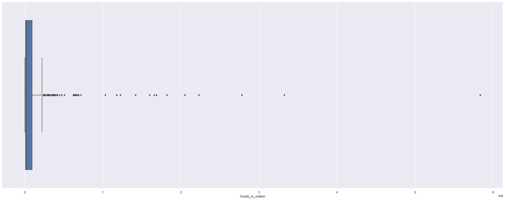

```python
sns.set(rc= {"figure.figsize": (32, 12)})
sns.boxplot(x="Funds_in_million",data=newcomp)
```

```python
#Check the number of outliers greater than the upper fence.
```

```python
newcomp.describe()
```

|  | Funds_in_million |
| --- | --- |
| count | 4.460000e+02 |
| mean | 1.342983e+07 |
| std | 4.254517e+07 |
| min | 1.700000e+00 |
| 25% | 7.240000e+05 |
| 50% | 2.200000e+06 |
| 75% | 9.350000e+06 |
| max | 5.836000e+08 |

```python
#IQR=Q3-Q1
#Upper fence = Q3 + (1.5 * IQR)
Q3 = np.quantile(newcomp['Funds_in_million'], 0.75)
Q1 = np.quantile(newcomp['Funds_in_million'], 0.25)
IQR = Q3 - Q1
```

```python
IQR
```

```
8626000.0
```

```python
Upperfence = Q3 + (1.5 * IQR)
Upperfence
```

```
22289000.0
```

```python
newcomp1 = newcomp[newcomp['Funds_in_million']>Upperfence]
num_rows, num_cols=newcomp1.shape
print("The number of outliers is: ",num_rows)
```

```
The number of outliers is:  59
```

```python
#Check frequency of the OperatingState features classes.
```

```python
count = newcomp.groupby('OperatingState').size()
co='OperatingState'
print("Frequency of values in column ", co, "is:\n",count)
```

```
Frequency of values in column  OperatingState is:
 OperatingState
Acquired      66
Closed        57
Ipo            4
Operating    319
dtype: int64
```